# Codebook for Data

Autogenerated data summary from dataMaid

2019-04-15 15:46:17

# Data report overview

The dataset examined has the following dimensions:

| Feature | Result |
| --- | --- |
| Number of observations | 1470 |
| Number of variables | 35 |

# Codebook summary table

| Label | Variable | Class | # unique values | Missing | Description |
| --- | --- | --- | --- | --- | --- |
|  | **Age** | numeric | 43 | 0.00 % |  |
|  | **Attrition** | character | 2 | 0.00 % |  |
|  | **Feq.Travel** | character | 3 | 0.00 % |  |
|  | **Daily.Rate** | numeric | 886 | 0.00 % |  |
|  | **Department** | character | 3 | 0.00 % |  |
|  | **mlg.Home** | numeric | 29 | 0.00 % |  |
|  | **Education** | numeric | 5 | 0.00 % |  |
|  | **Ed.Field** | character | 6 | 0.00 % |  |
|  | **Emp.Count** | numeric | 1 | 0.00 % |  |
|  | **Emp.Number** | numeric | 1470 | 0.00 % |  |
|  | **Env.Sat** | numeric | 4 | 0.00 % |  |
|  | **Gender** | character | 2 | 0.00 % |  |
|  | **HourlyRate** | numeric | 71 | 0.00 % |  |
|  | **Job.Invol** | numeric | 4 | 0.00 % |  |
|  | **Job.Level** | numeric | 5 | 0.00 % |  |
|  | **Title** | character | 9 | 0.00 % |  |
|  | **Satisfied** | numeric | 4 | 0.00 % |  |
|  | **M.S.D** | character | 3 | 0.00 % |  |
|  | **Income.mos** | numeric | 1349 | 0.00 % |  |
|  | **Rate.mos** | numeric | 1427 | 0.00 % |  |
|  | **Jobs.Worked** | numeric | 10 | 0.00 % |  |
|  | **Over18** | character | 1 | 0.00 % |  |
|  | **OT** | character | 2 | 0.00 % |  |
|  | **Percent.Inc** | numeric | 15 | 0.00 % |  |
|  | **Performance** | numeric | 2 | 0.00 % |  |
|  | **Sat.Relation** | numeric | 4 | 0.00 % |  |
|  | **Hours** | numeric | 1 | 0.00 % |  |
|  | **Stock** | numeric | 4 | 0.00 % |  |
|  | **Yrs.Wrkd** | numeric | 40 | 0.00 % |  |
|  | **Training** | numeric | 7 | 0.00 % |  |
|  | **Work.Life** | numeric | 4 | 0.00 % |  |
|  | **YOS** | numeric | 37 | 0.00 % |  |
|  | **YCRole** | numeric | 19 | 0.00 % |  |
|  | **YbtwnPromo** | numeric | 16 | 0.00 % |  |
|  | **YwMgmt** | numeric | 18 | 0.00 % |  |

# Variable list

## Age

| Feature | Result |
| --- | --- |
| Variable type | numeric |
| Number of missing obs. | 0 (0 %) |
| Number of unique values | 43 |
| Median | 36 |
| 1st and 3rd quartiles | 30; 43 |
| Min. and max. | 18; 60 |

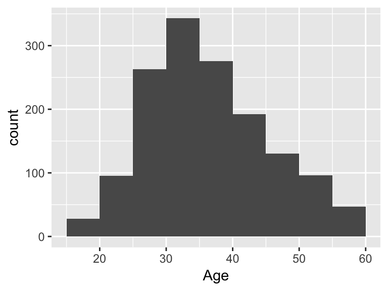

## Attrition

| Feature | Result |
| --- | --- |
| Variable type | character |
| Number of missing obs. | 0 (0 %) |
| Number of unique values | 2 |
| Mode | “No” |

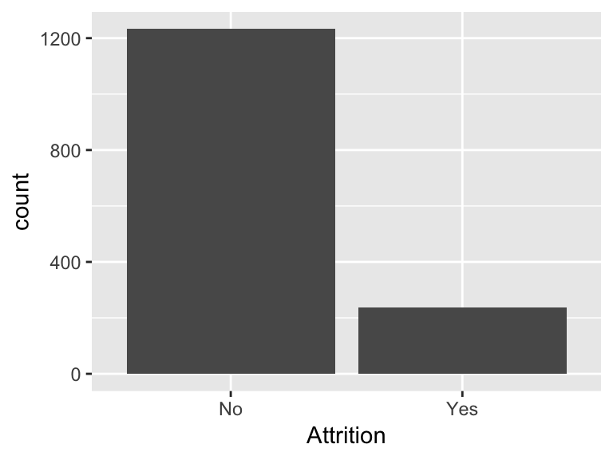

- Observed factor levels: "No", "Yes".

## Feq.Travel

| Feature | Result |
| --- | --- |
| Variable type | character |
| Number of missing obs. | 0 (0 %) |
| Number of unique values | 3 |
| Mode | “Travel_Rarely” |

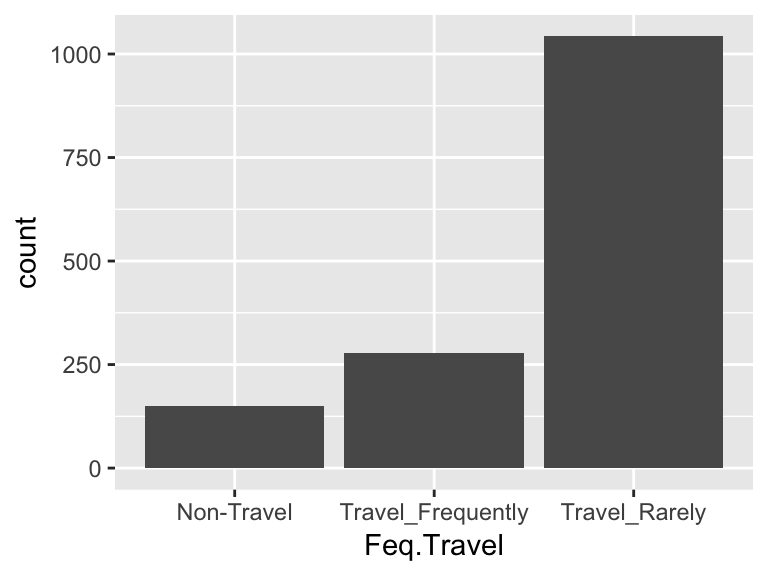

- Observed factor levels: "Non-Travel", "Travel_Frequently", "Travel_Rarely".

## Daily.Rate

| Feature | Result |
| --- | --- |
| Variable type | numeric |
| Number of missing obs. | 0 (0 %) |
| Number of unique values | 886 |
| Median | 802 |
| 1st and 3rd quartiles | 465; 1157 |
| Min. and max. | 102; 1499 |

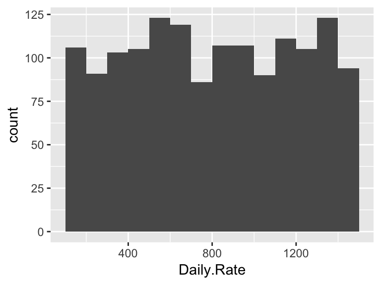

## Department

| Feature | Result |
| --- | --- |
| Variable type | character |
| Number of missing obs. | 0 (0 %) |
| Number of unique values | 3 |
| Mode | “Research & Development” |

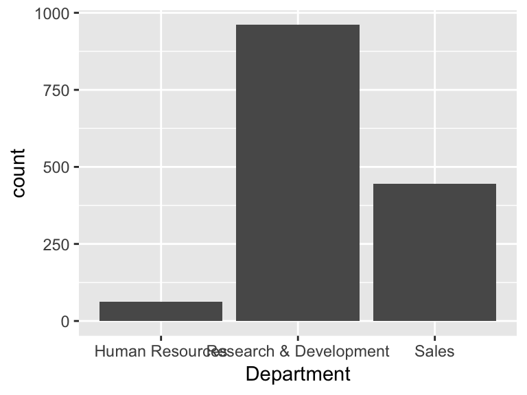

- Observed factor levels: "Human Resources", "Research & Development", "Sales".

## mlg.Home

| Feature | Result |
| --- | --- |
| Variable type | numeric |
| Number of missing obs. | 0 (0 %) |
| Number of unique values | 29 |
| Median | 7 |
| 1st and 3rd quartiles | 2; 14 |
| Min. and max. | 1; 29 |

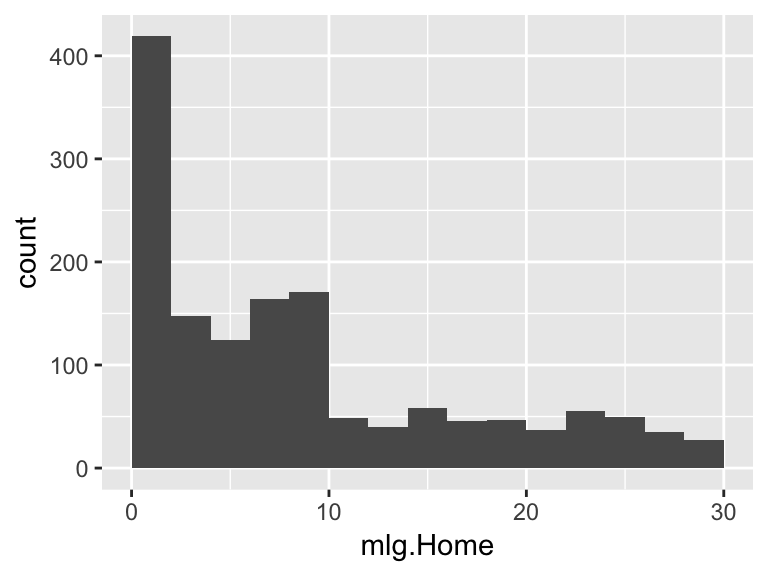

## Education

| Feature | Result |
| --- | --- |
| Variable type | numeric |
| Number of missing obs. | 0 (0 %) |
| Number of unique values | 5 |
| Median | 3 |
| 1st and 3rd quartiles | 2; 4 |
| Min. and max. | 1; 5 |

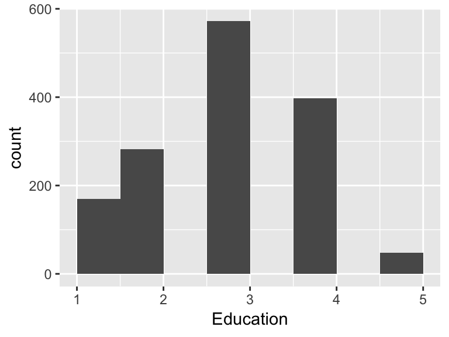

## Ed.Field

| Feature | Result |
| --- | --- |
| Variable type | character |
| Number of missing obs. | 0 (0 %) |
| Number of unique values | 6 |
| Mode | “Life Sciences” |

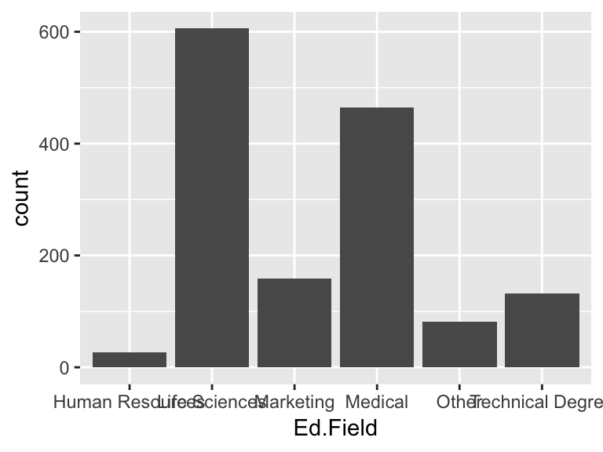

- Observed factor levels: "Human Resources", "Life Sciences", "Marketing", "Medical", "Other", "Technical Degree".

## Emp.Count

- The variable only takes one (non-missing) value: "1". The variable contains 0 % missing observations.

## Emp.Number

| Feature | Result |
| --- | --- |
| Variable type | numeric |
| Number of missing obs. | 0 (0 %) |
| Number of unique values | 1470 |
| Median | 1020.5 |
| 1st and 3rd quartiles | 491.25; 1555.75 |
| Min. and max. | 1; 2068 |

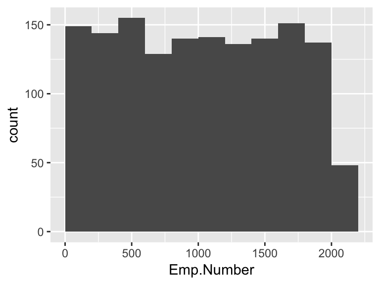

## Env.Sat

| Feature | Result |
| --- | --- |
| Variable type | numeric |
| Number of missing obs. | 0 (0 %) |
| Number of unique values | 4 |
| Median | 3 |
| 1st and 3rd quartiles | 2; 4 |
| Min. and max. | 1; 4 |

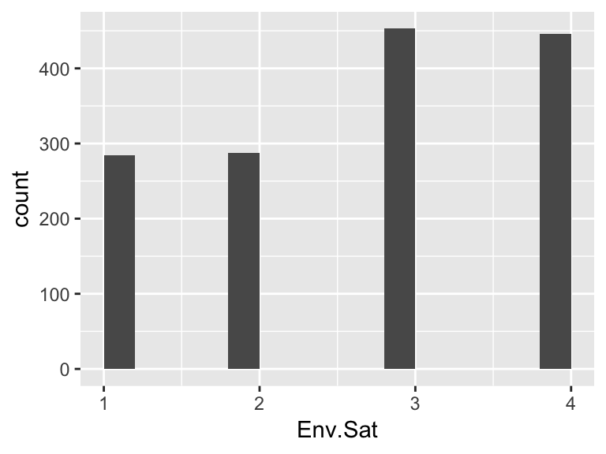

## Gender

| Feature | Result |
| --- | --- |
| Variable type | character |
| Number of missing obs. | 0 (0 %) |
| Number of unique values | 2 |
| Mode | “Male” |

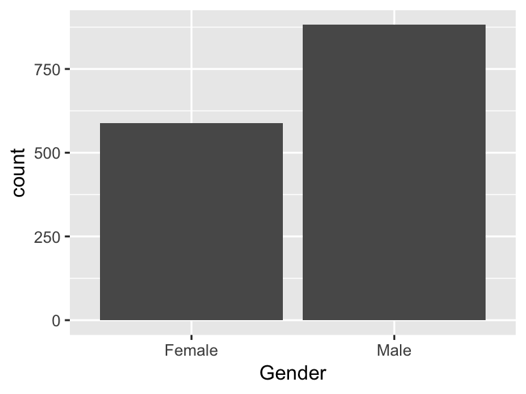

- Observed factor levels: "Female", "Male".

## HourlyRate

| Feature | Result |
| --- | --- |
| Variable type | numeric |
| Number of missing obs. | 0 (0 %) |
| Number of unique values | 71 |
| Median | 66 |
| 1st and 3rd quartiles | 48; 83.75 |
| Min. and max. | 30; 100 |

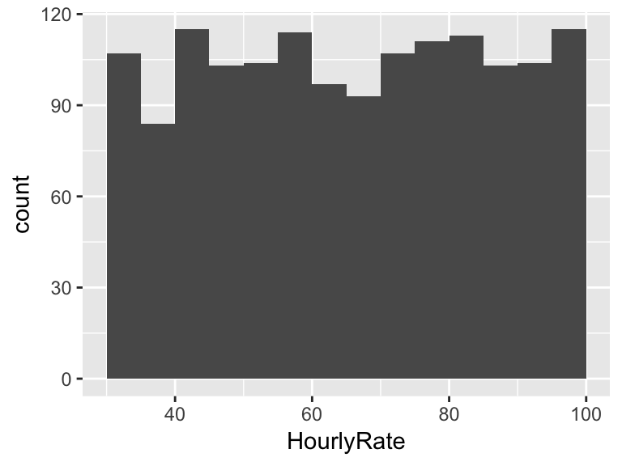

## Job.Invol

| Feature | Result |
| --- | --- |
| Variable type | numeric |
| Number of missing obs. | 0 (0 %) |
| Number of unique values | 4 |
| Median | 3 |
| 1st and 3rd quartiles | 2; 3 |
| Min. and max. | 1; 4 |

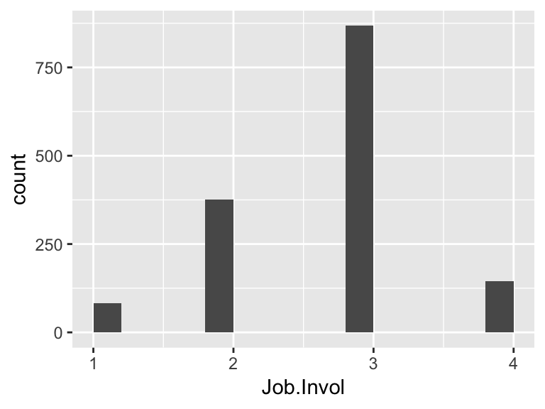

## Job.Level

| Feature | Result |
| --- | --- |
| Variable type | numeric |
| Number of missing obs. | 0 (0 %) |
| Number of unique values | 5 |
| Median | 2 |
| 1st and 3rd quartiles | 1; 3 |
| Min. and max. | 1; 5 |

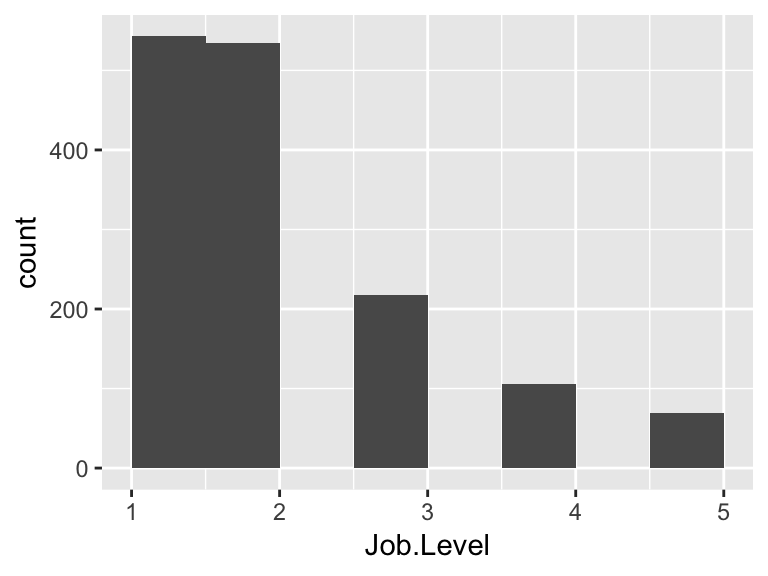

## Title

| Feature | Result |
| --- | --- |
| Variable type | character |
| Number of missing obs. | 0 (0 %) |
| Number of unique values | 9 |
| Mode | “Sales Executive” |

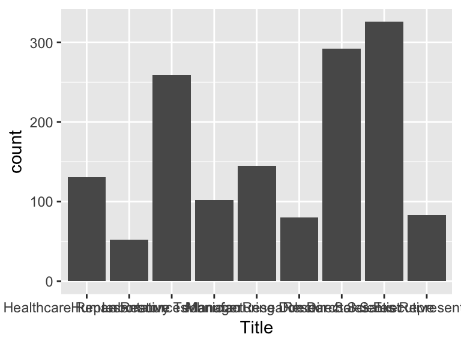

- Observed factor levels: "Healthcare Representative", "Human Resources", "Laboratory Technician", "Manager", "Manufacturing Director", "Research Director", "Research Scientist", "Sales Executive", "Sales Representative".

## Satisfied

| Feature | Result |
| --- | --- |
| Variable type | numeric |
| Number of missing obs. | 0 (0 %) |
| Number of unique values | 4 |
| Median | 3 |
| 1st and 3rd quartiles | 2; 4 |
| Min. and max. | 1; 4 |

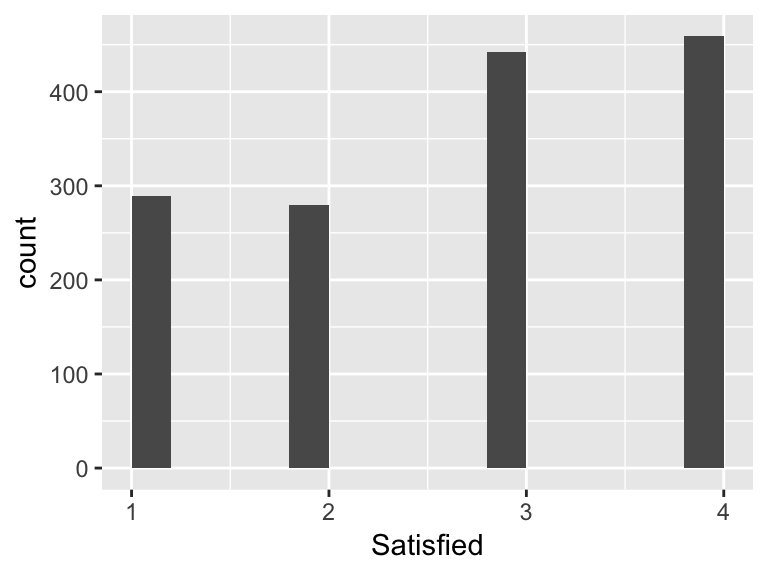

## M.S.D

| Feature | Result |
| --- | --- |
| Variable type | character |
| Number of missing obs. | 0 (0 %) |
| Number of unique values | 3 |
| Mode | “Married” |

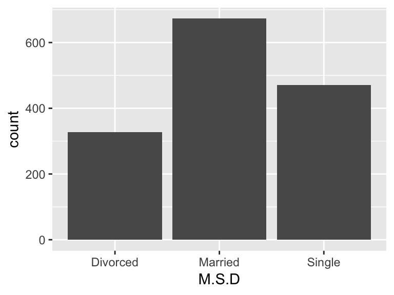

- Observed factor levels: "Divorced", "Married", "Single".

## Income.mos

| Feature | Result |
| --- | --- |
| Variable type | numeric |
| Number of missing obs. | 0 (0 %) |
| Number of unique values | 1349 |
| Median | 4919 |
| 1st and 3rd quartiles | 2911; 8379 |
| Min. and max. | 1009; 19999 |

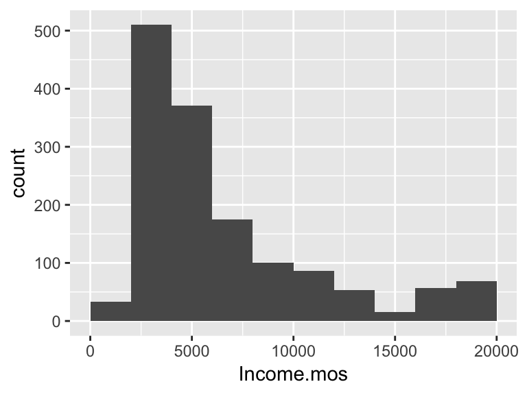

## Rate.mos

| Feature | Result |
| --- | --- |
| Variable type | numeric |
| Number of missing obs. | 0 (0 %) |
| Number of unique values | 1427 |
| Median | 14235.5 |
| 1st and 3rd quartiles | 8047; 20461.5 |
| Min. and max. | 2094; 26999 |

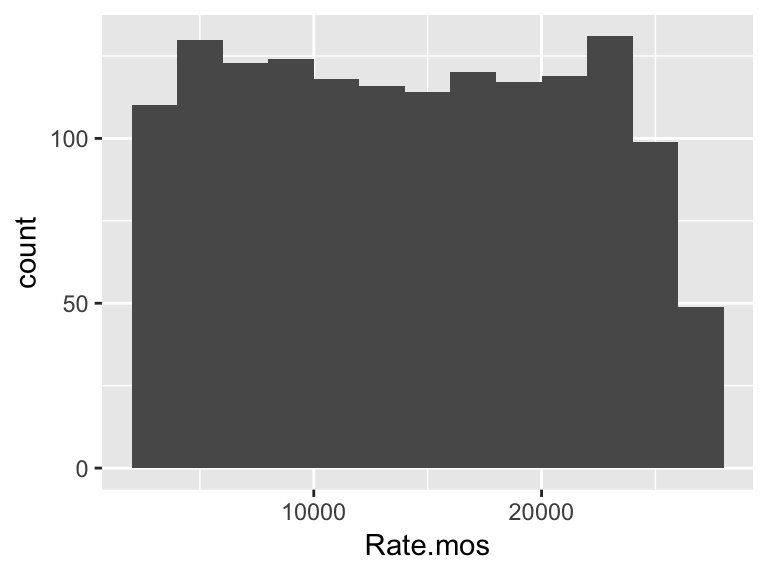

## Jobs.Worked

| Feature | Result |
| --- | --- |
| Variable type | numeric |
| Number of missing obs. | 0 (0 %) |
| Number of unique values | 10 |
| Median | 2 |
| 1st and 3rd quartiles | 1; 4 |
| Min. and max. | 0; 9 |

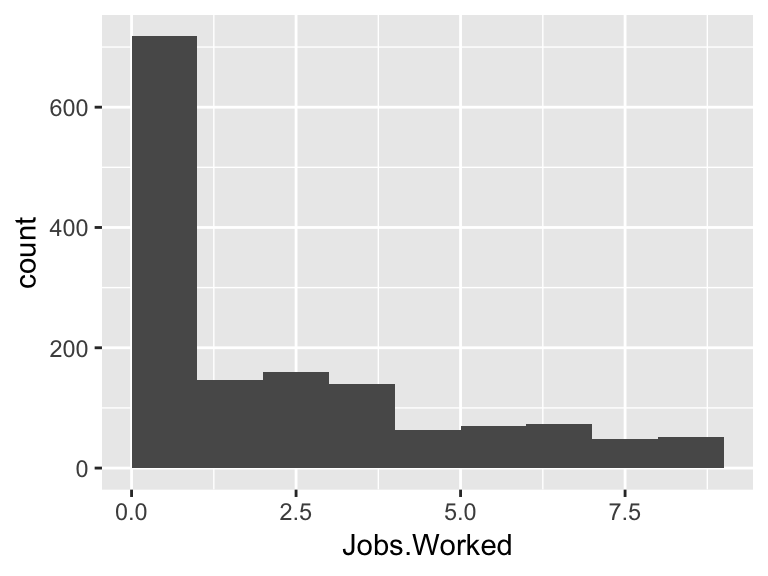

## Over18

- The variable only takes one (non-missing) value: "Y". The variable contains 0 % missing observations.

## OT

| Feature | Result |
| --- | --- |
| Variable type | character |
| Number of missing obs. | 0 (0 %) |
| Number of unique values | 2 |
| Mode | “No” |

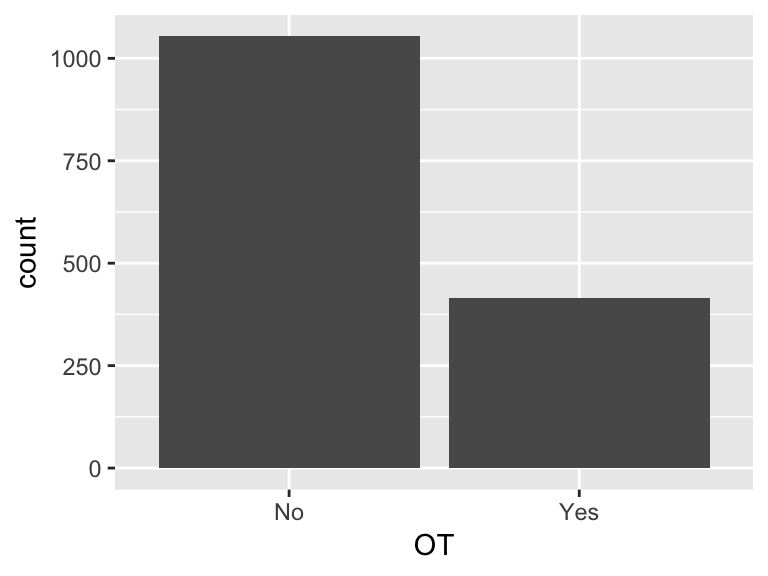

- Observed factor levels: "No", "Yes".

## Percent.Inc

| Feature | Result |
| --- | --- |
| Variable type | numeric |
| Number of missing obs. | 0 (0 %) |
| Number of unique values | 15 |
| Median | 14 |
| 1st and 3rd quartiles | 12; 18 |
| Min. and max. | 11; 25 |

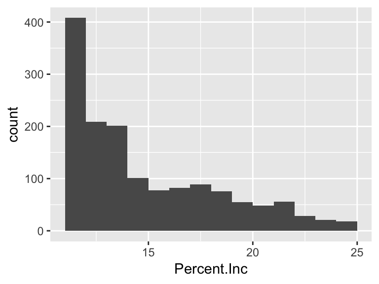

## Performance

| Feature | Result |
| --- | --- |
| Variable type | numeric |
| Number of missing obs. | 0 (0 %) |
| Number of unique values | 2 |
| Median | 3 |
| 1st and 3rd quartiles | 3; 3 |
| Min. and max. | 3; 4 |

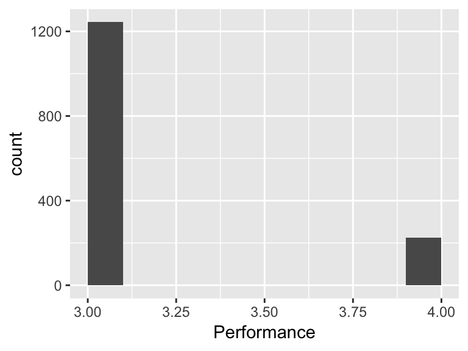

## Sat.Relation

| Feature | Result |
| --- | --- |
| Variable type | numeric |
| Number of missing obs. | 0 (0 %) |
| Number of unique values | 4 |
| Median | 3 |
| 1st and 3rd quartiles | 2; 4 |
| Min. and max. | 1; 4 |

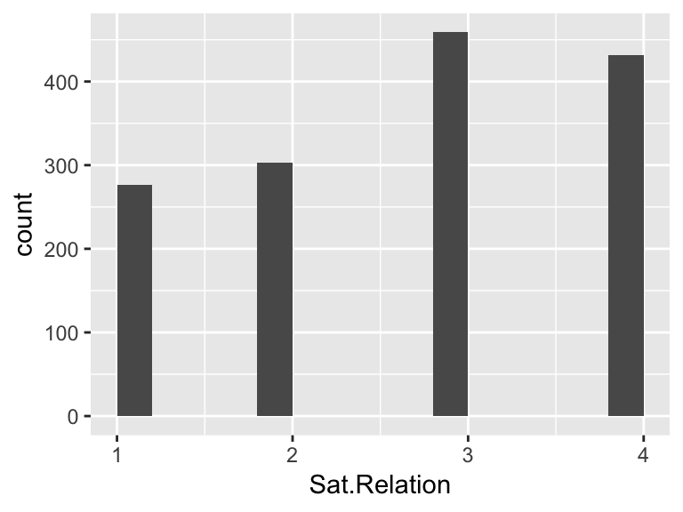

## Hours

- The variable only takes one (non-missing) value: "80". The variable contains 0 % missing observations.

## Stock

| Feature | Result |
| --- | --- |
| Variable type | numeric |
| Number of missing obs. | 0 (0 %) |
| Number of unique values | 4 |
| Median | 1 |
| 1st and 3rd quartiles | 0; 1 |
| Min. and max. | 0; 3 |

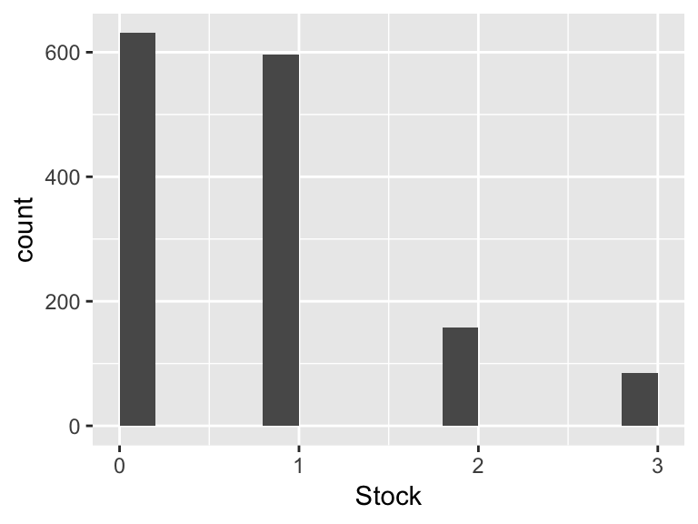

## Yrs.Wrkd

| Feature | Result |
| --- | --- |
| Variable type | numeric |
| Number of missing obs. | 0 (0 %) |
| Number of unique values | 40 |
| Median | 10 |
| 1st and 3rd quartiles | 6; 15 |
| Min. and max. | 0; 40 |

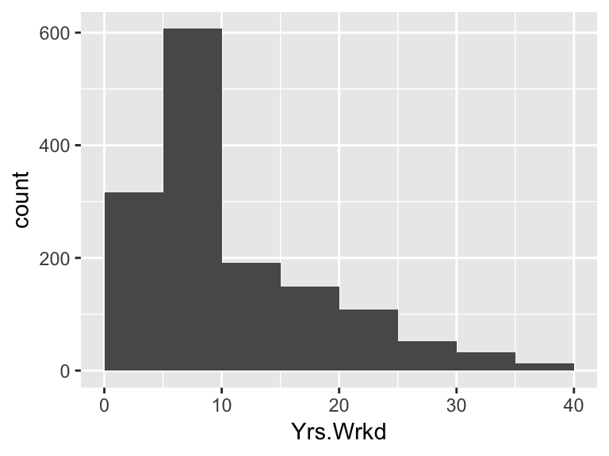

## Training

| Feature | Result |
| --- | --- |
| Variable type | numeric |
| Number of missing obs. | 0 (0 %) |
| Number of unique values | 7 |
| Median | 3 |
| 1st and 3rd quartiles | 2; 3 |
| Min. and max. | 0; 6 |

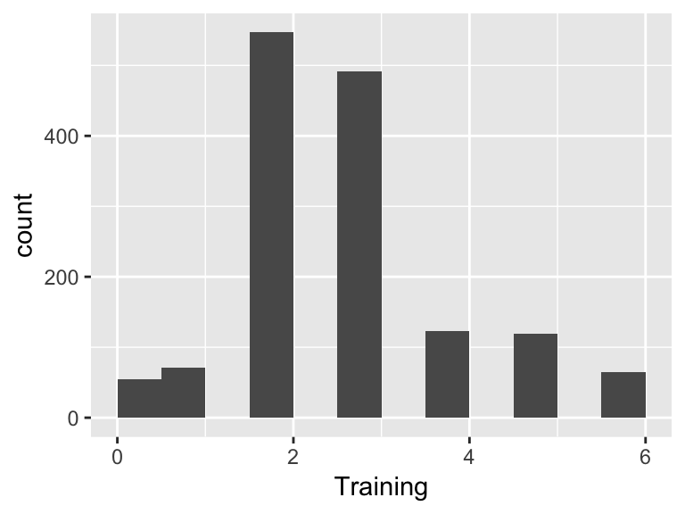

## Work.Life

| Feature | Result |
| --- | --- |
| Variable type | numeric |
| Number of missing obs. | 0 (0 %) |
| Number of unique values | 4 |
| Median | 3 |
| 1st and 3rd quartiles | 2; 3 |
| Min. and max. | 1; 4 |

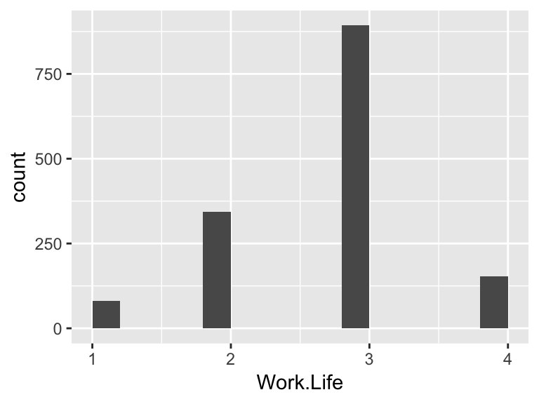

## YOS

| Feature | Result |
| --- | --- |
| Variable type | numeric |
| Number of missing obs. | 0 (0 %) |
| Number of unique values | 37 |
| Median | 5 |
| 1st and 3rd quartiles | 3; 9 |
| Min. and max. | 0; 40 |

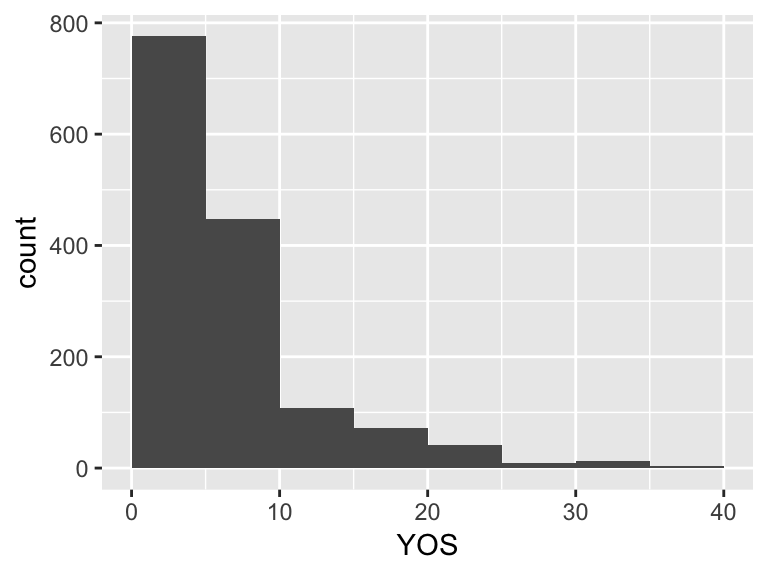

## YCRole

| Feature | Result |
| --- | --- |
| Variable type | numeric |
| Number of missing obs. | 0 (0 %) |
| Number of unique values | 19 |
| Median | 3 |
| 1st and 3rd quartiles | 2; 7 |
| Min. and max. | 0; 18 |

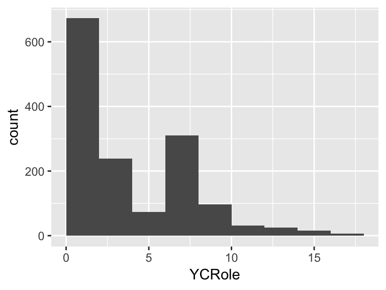

## YbtwnPromo

| Feature | Result |
| --- | --- |
| Variable type | numeric |
| Number of missing obs. | 0 (0 %) |
| Number of unique values | 16 |
| Median | 1 |
| 1st and 3rd quartiles | 0; 3 |
| Min. and max. | 0; 15 |

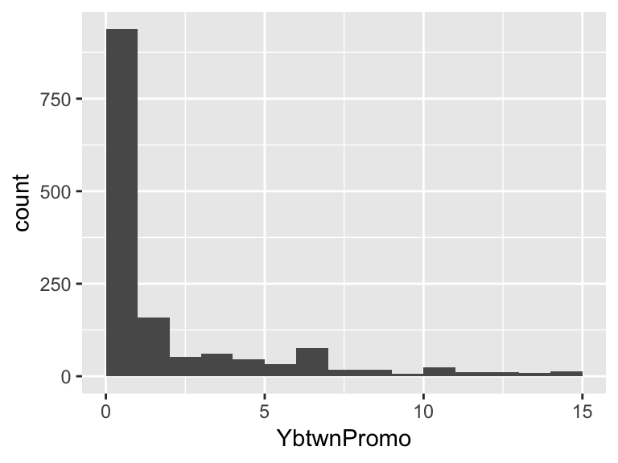

## YwMgmt

| Feature | Result |
| --- | --- |
| Variable type | numeric |
| Number of missing obs. | 0 (0 %) |
| Number of unique values | 18 |
| Median | 3 |
| 1st and 3rd quartiles | 2; 7 |
| Min. and max. | 0; 17 |

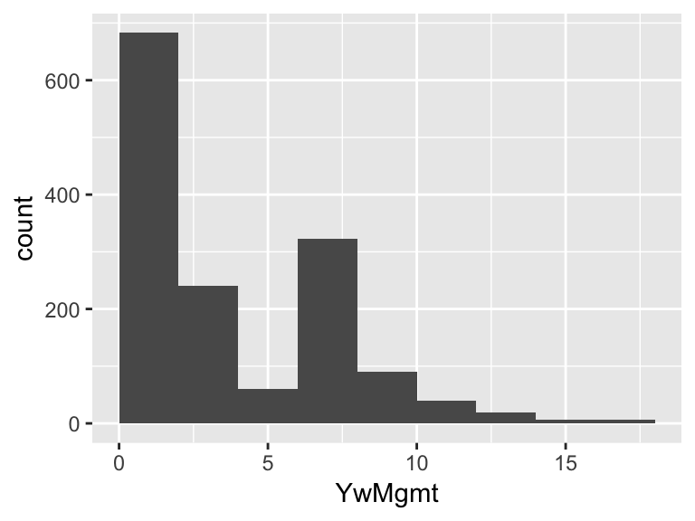

Report generation information:

- Created by K Theobald (username: `ktheobald`).
- Report creation time: Mon Apr 15 2019 15:46:17
- Report was run from directory: `/Users/ktheobald/Desktop/Kari/SMU /Doing Data Science/Homework/CaseStudy2/CaseStudy2`
- dataMaid v1.2.0 [Pkg: 2018-10-03 from CRAN (R 3.5.0)]
- R version 3.5.1 (2018-07-02).
- Platform: x86_64-apple-darwin15.6.0 (64-bit)(macOS Sierra 10.12.6).
- Function call: `makeDataReport(data = Data, mode = c("summarize", "visualize", "check"), smartNum = FALSE, file = "codebook_Data.Rmd", replace = TRUE, checks = list(character = "showAllFactorLevels", factor = "showAllFactorLevels", labelled = "showAllFactorLevels", haven_labelled = "showAllFactorLevels", numeric = NULL, integer = NULL, logical = NULL, Date = NULL), listChecks = FALSE, maxProbVals = Inf, codebook = TRUE, reportTitle = "Codebook for Data")`